# Risk Factor Analysis

## Outcome Variable

**Outcome Variable:** stunted

## Predictor Variables

**Intervention Variable:** birthwt

**Adjustment Set:**

- arm
- sex
- W_mage
- meducyrs
- feducyrs
- vagbrth
- single
- brthmon
- W_parity
- delta_W_mage
- delta_meducyrs
- delta_feducyrs
- delta_vagbrth
- delta_single
- delta_brthmon
- delta_W_parity

## Stratifying Variables

The analysis was stratified on these variable(s):

- agecat
- studyid
- country

## Data Summary

| agecat | studyid | country | birthwt | stunted | n_cell | n |
| --- | --- | --- | --- | --- | --- | --- |
| Birth | CMC-V-BCS-2002 | INDIA | Normal or high birthweight | 0 | 71 | 92 |
| Birth | CMC-V-BCS-2002 | INDIA | Normal or high birthweight | 1 | 10 | 92 |
| Birth | CMC-V-BCS-2002 | INDIA | Low birthweight | 0 | 4 | 92 |
| Birth | CMC-V-BCS-2002 | INDIA | Low birthweight | 1 | 7 | 92 |
| Birth | CMIN | BANGLADESH | Normal or high birthweight | 0 | 13 | 26 |
| Birth | CMIN | BANGLADESH | Normal or high birthweight | 1 | 1 | 26 |
| Birth | CMIN | BANGLADESH | Low birthweight | 0 | 4 | 26 |
| Birth | CMIN | BANGLADESH | Low birthweight | 1 | 8 | 26 |
| Birth | COHORTS | GUATEMALA | Normal or high birthweight | 0 | 695 | 784 |
| Birth | COHORTS | GUATEMALA | Normal or high birthweight | 1 | 22 | 784 |
| Birth | COHORTS | GUATEMALA | Low birthweight | 0 | 43 | 784 |
| Birth | COHORTS | GUATEMALA | Low birthweight | 1 | 24 | 784 |
| Birth | COHORTS | INDIA | Normal or high birthweight | 0 | 5059 | 6638 |
| Birth | COHORTS | INDIA | Normal or high birthweight | 1 | 209 | 6638 |
| Birth | COHORTS | INDIA | Low birthweight | 0 | 787 | 6638 |
| Birth | COHORTS | INDIA | Low birthweight | 1 | 583 | 6638 |
| Birth | COHORTS | PHILIPPINES | Normal or high birthweight | 0 | 2643 | 3004 |
| Birth | COHORTS | PHILIPPINES | Normal or high birthweight | 1 | 66 | 3004 |
| Birth | COHORTS | PHILIPPINES | Low birthweight | 0 | 181 | 3004 |
| Birth | COHORTS | PHILIPPINES | Low birthweight | 1 | 114 | 3004 |
| Birth | CONTENT | PERU | Normal or high birthweight | 0 | 2 | 2 |
| Birth | CONTENT | PERU | Normal or high birthweight | 1 | 0 | 2 |
| Birth | CONTENT | PERU | Low birthweight | 0 | 0 | 2 |
| Birth | CONTENT | PERU | Low birthweight | 1 | 0 | 2 |
| Birth | EE | PAKISTAN | Normal or high birthweight | 0 | 112 | 240 |
| Birth | EE | PAKISTAN | Normal or high birthweight | 1 | 48 | 240 |
| Birth | EE | PAKISTAN | Low birthweight | 0 | 28 | 240 |
| Birth | EE | PAKISTAN | Low birthweight | 1 | 52 | 240 |
| Birth | GMS-Nepal | NEPAL | Normal or high birthweight | 0 | 453 | 696 |
| Birth | GMS-Nepal | NEPAL | Normal or high birthweight | 1 | 23 | 696 |

[output cut: 282 more lines]

The following strata were considered:

- agecat: 24 months, studyid: CMC-V-BCS-2002, country: INDIA
- agecat: 24 months, studyid: CMIN, country: BANGLADESH
- agecat: 24 months, studyid: COHORTS, country: GUATEMALA
- agecat: 24 months, studyid: COHORTS, country: INDIA
- agecat: 24 months, studyid: COHORTS, country: PHILIPPINES
- agecat: 24 months, studyid: CONTENT, country: PERU
- agecat: 24 months, studyid: EE, country: PAKISTAN
- agecat: 24 months, studyid: GMS-Nepal, country: NEPAL
- agecat: 24 months, studyid: IRC, country: INDIA
- agecat: 24 months, studyid: JiVitA-3, country: BANGLADESH
- agecat: 24 months, studyid: JiVitA-4, country: BANGLADESH
- agecat: 24 months, studyid: Keneba, country: GAMBIA
- agecat: 24 months, studyid: MAL-ED, country: BANGLADESH
- agecat: 24 months, studyid: MAL-ED, country: BRAZIL
- agecat: 24 months, studyid: MAL-ED, country: INDIA
- agecat: 24 months, studyid: MAL-ED, country: NEPAL
- agecat: 24 months, studyid: MAL-ED, country: PERU
- agecat: 24 months, studyid: MAL-ED, country: SOUTH AFRICA
- agecat: 24 months, studyid: MAL-ED, country: TANZANIA, UNITED REPUBLIC OF
- agecat: 24 months, studyid: NIH-Birth, country: BANGLADESH
- agecat: 24 months, studyid: NIH-Crypto, country: BANGLADESH
- agecat: 24 months, studyid: PROBIT, country: BELARUS
- agecat: 24 months, studyid: PROVIDE, country: BANGLADESH
- agecat: 24 months, studyid: TanzaniaChild2, country: TANZANIA, UNITED REPUBLIC OF
- agecat: 24 months, studyid: ZVITAMBO, country: ZIMBABWE
- agecat: 6 months, studyid: CMC-V-BCS-2002, country: INDIA
- agecat: 6 months, studyid: CMIN, country: BANGLADESH
- agecat: 6 months, studyid: COHORTS, country: GUATEMALA
- agecat: 6 months, studyid: COHORTS, country: INDIA
- agecat: 6 months, studyid: COHORTS, country: PHILIPPINES
- agecat: 6 months, studyid: CONTENT, country: PERU
- agecat: 6 months, studyid: EE, country: PAKISTAN
- agecat: 6 months, studyid: GMS-Nepal, country: NEPAL
- agecat: 6 months, studyid: IRC, country: INDIA
- agecat: 6 months, studyid: JiVitA-3, country: BANGLADESH
- agecat: 6 months, studyid: JiVitA-4, country: BANGLADESH
- agecat: 6 months, studyid: Keneba, country: GAMBIA
- agecat: 6 months, studyid: MAL-ED, country: BANGLADESH
- agecat: 6 months, studyid: MAL-ED, country: BRAZIL
- agecat: 6 months, studyid: MAL-ED, country: INDIA
- agecat: 6 months, studyid: MAL-ED, country: NEPAL
- agecat: 6 months, studyid: MAL-ED, country: PERU
- agecat: 6 months, studyid: MAL-ED, country: SOUTH AFRICA
- agecat: 6 months, studyid: MAL-ED, country: TANZANIA, UNITED REPUBLIC OF
- agecat: 6 months, studyid: NIH-Birth, country: BANGLADESH
- agecat: 6 months, studyid: NIH-Crypto, country: BANGLADESH
- agecat: 6 months, studyid: PROBIT, country: BELARUS
- agecat: 6 months, studyid: PROVIDE, country: BANGLADESH
- agecat: 6 months, studyid: ResPak, country: PAKISTAN
- agecat: 6 months, studyid: SAS-CompFeed, country: INDIA
- agecat: 6 months, studyid: TanzaniaChild2, country: TANZANIA, UNITED REPUBLIC OF
- agecat: 6 months, studyid: ZVITAMBO, country: ZIMBABWE
- agecat: Birth, studyid: CMC-V-BCS-2002, country: INDIA
- agecat: Birth, studyid: CMIN, country: BANGLADESH
- agecat: Birth, studyid: COHORTS, country: GUATEMALA
- agecat: Birth, studyid: COHORTS, country: INDIA
- agecat: Birth, studyid: COHORTS, country: PHILIPPINES
- agecat: Birth, studyid: CONTENT, country: PERU
- agecat: Birth, studyid: EE, country: PAKISTAN
- agecat: Birth, studyid: GMS-Nepal, country: NEPAL
- agecat: Birth, studyid: IRC, country: INDIA
- agecat: Birth, studyid: JiVitA-3, country: BANGLADESH
- agecat: Birth, studyid: JiVitA-4, country: BANGLADESH
- agecat: Birth, studyid: Keneba, country: GAMBIA
- agecat: Birth, studyid: MAL-ED, country: BANGLADESH
- agecat: Birth, studyid: MAL-ED, country: BRAZIL
- agecat: Birth, studyid: MAL-ED, country: INDIA
- agecat: Birth, studyid: MAL-ED, country: NEPAL
- agecat: Birth, studyid: MAL-ED, country: PERU
- agecat: Birth, studyid: MAL-ED, country: SOUTH AFRICA
- agecat: Birth, studyid: MAL-ED, country: TANZANIA, UNITED REPUBLIC OF
- agecat: Birth, studyid: NIH-Birth, country: BANGLADESH
- agecat: Birth, studyid: NIH-Crypto, country: BANGLADESH
- agecat: Birth, studyid: PROBIT, country: BELARUS
- agecat: Birth, studyid: PROVIDE, country: BANGLADESH
- agecat: Birth, studyid: ResPak, country: PAKISTAN
- agecat: Birth, studyid: SAS-CompFeed, country: INDIA
- agecat: Birth, studyid: ZVITAMBO, country: ZIMBABWE

### Dropped Strata

Some strata were dropped due to rare outcomes:

- agecat: Birth, studyid: CMC-V-BCS-2002, country: INDIA
- agecat: Birth, studyid: CMIN, country: BANGLADESH
- agecat: Birth, studyid: CONTENT, country: PERU
- agecat: Birth, studyid: MAL-ED, country: BRAZIL
- agecat: Birth, studyid: MAL-ED, country: INDIA
- agecat: Birth, studyid: MAL-ED, country: NEPAL
- agecat: Birth, studyid: MAL-ED, country: PERU
- agecat: Birth, studyid: MAL-ED, country: SOUTH AFRICA
- agecat: Birth, studyid: MAL-ED, country: TANZANIA, UNITED REPUBLIC OF
- agecat: Birth, studyid: PROBIT, country: BELARUS
- agecat: Birth, studyid: ResPak, country: PAKISTAN
- agecat: 6 months, studyid: CMIN, country: BANGLADESH
- agecat: 6 months, studyid: CONTENT, country: PERU
- agecat: 6 months, studyid: MAL-ED, country: BRAZIL
- agecat: 6 months, studyid: MAL-ED, country: NEPAL
- agecat: 6 months, studyid: MAL-ED, country: TANZANIA, UNITED REPUBLIC OF
- agecat: 6 months, studyid: PROBIT, country: BELARUS
- agecat: 6 months, studyid: ResPak, country: PAKISTAN
- agecat: 24 months, studyid: CMIN, country: BANGLADESH
- agecat: 24 months, studyid: COHORTS, country: GUATEMALA
- agecat: 24 months, studyid: CONTENT, country: PERU
- agecat: 24 months, studyid: MAL-ED, country: BRAZIL
- agecat: 24 months, studyid: MAL-ED, country: PERU
- agecat: 24 months, studyid: MAL-ED, country: SOUTH AFRICA
- agecat: 24 months, studyid: MAL-ED, country: TANZANIA, UNITED REPUBLIC OF
- agecat: 24 months, studyid: PROBIT, country: BELARUS
- agecat: 24 months, studyid: TanzaniaChild2, country: TANZANIA, UNITED REPUBLIC OF

## Methods Detail

We’re interested in the causal parameters $E[Y_a]$ for all values of $a \in \mathcal{A}$. These parameters represent the mean outcome if, possibly contrary to fact, we intervened to set all units to have $A=a$. Under the randomization and positivity assumptions, these are identified by the statistical parameters $\psi_a=E_W[E_{Y|A,W}(Y|A=a,W)]$. In addition, we’re interested in the mean of $Y$, $E[Y]$ under no intervention (the observed mean). We will estimate these parameters by using SuperLearner to fit the relevant likelihood factors – $E_{Y|A,W}(Y|A=a,W)$ and $p(A=a|W)$, and then updating our likelihood fit using a joint TMLE.

For unadjusted analyses ($W=\{\}$), initial likelihoods were estimated using Lrnr_glm to estimate the simple $E(Y|A)$ and Lrnr_mean to estimate $p(A)$. For adjusted analyses, a small library containing Lrnr_glmnet, Lrnr_xgboost, and Lrnr_mean was used.

Having estimated these parameters, we will then use the delta method to estimate relative risks and attributable risks relative to a prespecified baseline level of $A$.

# Results Detail

## Results Plots

[figure not shown]

[figure not shown]

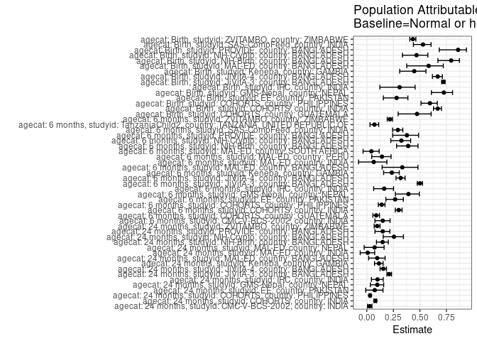

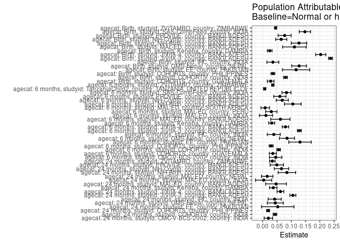

## Results Table

### Parameter: TSM

| agecat | studyid | country | intervention_level | baseline_level | estimate | ci_lower | ci_upper |
| --- | --- | --- | --- | --- | --- | --- | --- |
| Birth | COHORTS | GUATEMALA | Normal or high birthweight | NA | 0.0309127 | 0.0182426 | 0.0435829 |
| Birth | COHORTS | GUATEMALA | Low birthweight | NA | 0.3492544 | 0.2366102 | 0.4618986 |
| Birth | COHORTS | INDIA | Normal or high birthweight | NA | 0.0396130 | 0.0343410 | 0.0448849 |
| Birth | COHORTS | INDIA | Low birthweight | NA | 0.4220204 | 0.3955181 | 0.4485228 |
| Birth | COHORTS | PHILIPPINES | Normal or high birthweight | NA | 0.0242905 | 0.0184915 | 0.0300894 |
| Birth | COHORTS | PHILIPPINES | Low birthweight | NA | 0.3876813 | 0.3307310 | 0.4446315 |
| Birth | EE | PAKISTAN | Normal or high birthweight | NA | 0.2998203 | 0.2279940 | 0.3716466 |
| Birth | EE | PAKISTAN | Low birthweight | NA | 0.6475372 | 0.5412915 | 0.7537829 |
| Birth | GMS-Nepal | NEPAL | Normal or high birthweight | NA | 0.0480531 | 0.0287373 | 0.0673689 |
| Birth | GMS-Nepal | NEPAL | Low birthweight | NA | 0.4447346 | 0.3784672 | 0.5110021 |
| Birth | IRC | INDIA | Normal or high birthweight | NA | 0.0794164 | 0.0496384 | 0.1091945 |
| Birth | IRC | INDIA | Low birthweight | NA | 0.2765644 | 0.1622717 | 0.3908570 |
| Birth | JiVitA-3 | BANGLADESH | Normal or high birthweight | NA | 0.0915671 | 0.0857095 | 0.0974247 |
| Birth | JiVitA-3 | BANGLADESH | Low birthweight | NA | 0.6458201 | 0.6352749 | 0.6563654 |
| Birth | JiVitA-4 | BANGLADESH | Normal or high birthweight | NA | 0.1007428 | 0.0841681 | 0.1173176 |
| Birth | JiVitA-4 | BANGLADESH | Low birthweight | NA | 0.6578392 | 0.6236307 | 0.6920477 |
| Birth | Keneba | GAMBIA | Normal or high birthweight | NA | 0.0300195 | 0.0207807 | 0.0392582 |
| Birth | Keneba | GAMBIA | Low birthweight | NA | 0.1728009 | 0.1215160 | 0.2240858 |
| Birth | MAL-ED | BANGLADESH | Normal or high birthweight | NA | 0.0795196 | 0.0395944 | 0.1194449 |
| Birth | MAL-ED | BANGLADESH | Low birthweight | NA | 0.5561797 | 0.4169482 | 0.6954112 |
| Birth | NIH-Birth | BANGLADESH | Normal or high birthweight | NA | 0.0326722 | 0.0156257 | 0.0497186 |
| Birth | NIH-Birth | BANGLADESH | Low birthweight | NA | 0.4494427 | 0.3770011 | 0.5218843 |
| Birth | NIH-Crypto | BANGLADESH | Normal or high birthweight | NA | 0.0733517 | 0.0515981 | 0.0951053 |
| Birth | NIH-Crypto | BANGLADESH | Low birthweight | NA | 0.3437934 | 0.2720018 | 0.4155850 |
| Birth | PROVIDE | BANGLADESH | Normal or high birthweight | NA | 0.0124378 | 0.0015937 | 0.0232819 |
| Birth | PROVIDE | BANGLADESH | Low birthweight | NA | 0.3138686 | 0.2360885 | 0.3916487 |
| Birth | SAS-CompFeed | INDIA | Normal or high birthweight | NA | 0.1311687 | 0.0977428 | 0.1645946 |
| Birth | SAS-CompFeed | INDIA | Low birthweight | NA | 0.6714012 | 0.6099850 | 0.7328175 |
| Birth | ZVITAMBO | ZIMBABWE | Normal or high birthweight | NA | 0.0585824 | 0.0543683 | 0.0627965 |
| Birth | ZVITAMBO | ZIMBABWE | Low birthweight | NA | 0.3856682 | 0.3637456 | 0.4075908 |

[output cut: 72 more lines]

### Parameter: E(Y)

| agecat | studyid | country | intervention_level | baseline_level | estimate | ci_lower | ci_upper |
| --- | --- | --- | --- | --- | --- | --- | --- |
| Birth | COHORTS | GUATEMALA | NA | NA | 0.0586735 | 0.0422124 | 0.0751345 |
| Birth | COHORTS | INDIA | NA | NA | 0.1193130 | 0.1115144 | 0.1271117 |
| Birth | COHORTS | PHILIPPINES | NA | NA | 0.0599201 | 0.0514314 | 0.0684088 |
| Birth | EE | PAKISTAN | NA | NA | 0.4166667 | 0.3541635 | 0.4791698 |
| Birth | GMS-Nepal | NEPAL | NA | NA | 0.1752874 | 0.1470202 | 0.2035545 |
| Birth | IRC | INDIA | NA | NA | 0.1148825 | 0.0829051 | 0.1468600 |
| Birth | JiVitA-3 | BANGLADESH | NA | NA | 0.3289392 | 0.3215744 | 0.3363039 |
| Birth | JiVitA-4 | BANGLADESH | NA | NA | 0.3035778 | 0.2836422 | 0.3235133 |
| Birth | Keneba | GAMBIA | NA | NA | 0.0542838 | 0.0429232 | 0.0656445 |
| Birth | MAL-ED | BANGLADESH | NA | NA | 0.1904762 | 0.1397281 | 0.2412242 |
| Birth | NIH-Birth | BANGLADESH | NA | NA | 0.1595395 | 0.1304091 | 0.1886699 |
| Birth | NIH-Crypto | BANGLADESH | NA | NA | 0.1379781 | 0.1129774 | 0.1629789 |
| Birth | PROVIDE | BANGLADESH | NA | NA | 0.0890538 | 0.0649864 | 0.1131212 |
| Birth | SAS-CompFeed | INDIA | NA | NA | 0.2787540 | 0.2475949 | 0.3099131 |
| Birth | ZVITAMBO | ZIMBABWE | NA | NA | 0.1035430 | 0.0984652 | 0.1086208 |
| 6 months | CMC-V-BCS-2002 | INDIA | NA | NA | 0.3019391 | 0.2545145 | 0.3493636 |
| 6 months | COHORTS | GUATEMALA | NA | NA | 0.4007782 | 0.3661645 | 0.4353920 |
| 6 months | COHORTS | INDIA | NA | NA | 0.1852739 | 0.1756495 | 0.1948983 |
| 6 months | COHORTS | PHILIPPINES | NA | NA | 0.2108027 | 0.1953170 | 0.2262884 |
| 6 months | EE | PAKISTAN | NA | NA | 0.4892473 | 0.4383809 | 0.5401137 |
| 6 months | GMS-Nepal | NEPAL | NA | NA | 0.2166963 | 0.1826342 | 0.2507583 |
| 6 months | IRC | INDIA | NA | NA | 0.2369077 | 0.1952403 | 0.2785751 |
| 6 months | JiVitA-3 | BANGLADESH | NA | NA | 0.2562633 | 0.2474260 | 0.2651005 |
| 6 months | JiVitA-4 | BANGLADESH | NA | NA | 0.2496907 | 0.2335617 | 0.2658197 |
| 6 months | Keneba | GAMBIA | NA | NA | 0.1334333 | 0.1151789 | 0.1516876 |
| 6 months | MAL-ED | BANGLADESH | NA | NA | 0.1848739 | 0.1354515 | 0.2342964 |
| 6 months | MAL-ED | INDIA | NA | NA | 0.1718062 | 0.1226272 | 0.2209851 |
| 6 months | MAL-ED | PERU | NA | NA | 0.2111111 | 0.1623431 | 0.2598792 |
| 6 months | MAL-ED | SOUTH AFRICA | NA | NA | 0.1976285 | 0.1484630 | 0.2467939 |
| 6 months | NIH-Birth | BANGLADESH | NA | NA | 0.2702703 | 0.2319893 | 0.3085512 |
| 6 months | NIH-Crypto | BANGLADESH | NA | NA | 0.2097902 | 0.1799252 | 0.2396552 |
| 6 months | PROVIDE | BANGLADESH | NA | NA | 0.1589404 | 0.1297581 | 0.1881227 |
| 6 months | SAS-CompFeed | INDIA | NA | NA | 0.2843137 | 0.2660295 | 0.3025980 |
| 6 months | TanzaniaChild2 | TANZANIA, UNITED REPUBLIC OF | NA | NA | 0.0964694 | 0.0835627 | 0.1093762 |
| 6 months | ZVITAMBO | ZIMBABWE | NA | NA | 0.1626911 | 0.1549064 | 0.1704758 |
| 24 months | CMC-V-BCS-2002 | INDIA | NA | NA | 0.7134986 | 0.6669235 | 0.7600737 |
| 24 months | COHORTS | INDIA | NA | NA | 0.5339646 | 0.5199355 | 0.5479937 |
| 24 months | COHORTS | PHILIPPINES | NA | NA | 0.6205320 | 0.6011383 | 0.6399257 |
| 24 months | EE | PAKISTAN | NA | NA | 0.7065868 | 0.6373214 | 0.7758523 |
| 24 months | GMS-Nepal | NEPAL | NA | NA | 0.4476386 | 0.4034301 | 0.4918471 |
| 24 months | IRC | INDIA | NA | NA | 0.4168734 | 0.3686766 | 0.4650703 |
| 24 months | JiVitA-3 | BANGLADESH | NA | NA | 0.4997947 | 0.4858988 | 0.5136907 |
| 24 months | JiVitA-4 | BANGLADESH | NA | NA | 0.3990025 | 0.3802617 | 0.4177433 |
| 24 months | Keneba | GAMBIA | NA | NA | 0.3229167 | 0.2947011 | 0.3511322 |
| 24 months | MAL-ED | BANGLADESH | NA | NA | 0.4761905 | 0.4084806 | 0.5439003 |
| 24 months | MAL-ED | INDIA | NA | NA | 0.4174312 | 0.3518190 | 0.4830433 |
| 24 months | MAL-ED | NEPAL | NA | NA | 0.2126697 | 0.1585982 | 0.2667411 |
| 24 months | NIH-Birth | BANGLADESH | NA | NA | 0.5700483 | 0.5223021 | 0.6177945 |
| 24 months | NIH-Crypto | BANGLADESH | NA | NA | 0.2568093 | 0.2190047 | 0.2946140 |
| 24 months | PROVIDE | BANGLADESH | NA | NA | 0.3287197 | 0.2903909 | 0.3670485 |
| 24 months | ZVITAMBO | ZIMBABWE | NA | NA | 0.3461774 | 0.3231098 | 0.3692449 |

### Parameter: RR

| agecat | studyid | country | intervention_level | baseline_level | estimate | ci_lower | ci_upper |
| --- | --- | --- | --- | --- | --- | --- | --- |
| Birth | COHORTS | GUATEMALA | Normal or high birthweight | Normal or high birthweight | 1.000000 | 1.0000000 | 1.000000 |
| Birth | COHORTS | GUATEMALA | Low birthweight | Normal or high birthweight | 11.298072 | 6.7049369 | 19.037678 |
| Birth | COHORTS | INDIA | Normal or high birthweight | Normal or high birthweight | 1.000000 | 1.0000000 | 1.000000 |
| Birth | COHORTS | INDIA | Low birthweight | Normal or high birthweight | 10.653591 | 9.1960745 | 12.342114 |
| Birth | COHORTS | PHILIPPINES | Normal or high birthweight | Normal or high birthweight | 1.000000 | 1.0000000 | 1.000000 |
| Birth | COHORTS | PHILIPPINES | Low birthweight | Normal or high birthweight | 15.960226 | 12.0580926 | 21.125132 |
| Birth | EE | PAKISTAN | Normal or high birthweight | Normal or high birthweight | 1.000000 | 1.0000000 | 1.000000 |
| Birth | EE | PAKISTAN | Low birthweight | Normal or high birthweight | 2.159751 | 1.6143172 | 2.889473 |
| Birth | GMS-Nepal | NEPAL | Normal or high birthweight | Normal or high birthweight | 1.000000 | 1.0000000 | 1.000000 |
| Birth | GMS-Nepal | NEPAL | Low birthweight | Normal or high birthweight | 9.255064 | 6.0262687 | 14.213805 |
| Birth | IRC | INDIA | Normal or high birthweight | Normal or high birthweight | 1.000000 | 1.0000000 | 1.000000 |
| Birth | IRC | INDIA | Low birthweight | Normal or high birthweight | 3.482457 | 1.9977993 | 6.070434 |
| Birth | JiVitA-3 | BANGLADESH | Normal or high birthweight | Normal or high birthweight | 1.000000 | 1.0000000 | 1.000000 |
| Birth | JiVitA-3 | BANGLADESH | Low birthweight | Normal or high birthweight | 7.052972 | 6.6110926 | 7.524385 |
| Birth | JiVitA-4 | BANGLADESH | Normal or high birthweight | Normal or high birthweight | 1.000000 | 1.0000000 | 1.000000 |
| Birth | JiVitA-4 | BANGLADESH | Low birthweight | Normal or high birthweight | 6.529886 | 5.4929732 | 7.762539 |
| Birth | Keneba | GAMBIA | Normal or high birthweight | Normal or high birthweight | 1.000000 | 1.0000000 | 1.000000 |
| Birth | Keneba | GAMBIA | Low birthweight | Normal or high birthweight | 5.756298 | 3.7498715 | 8.836294 |
| Birth | MAL-ED | BANGLADESH | Normal or high birthweight | Normal or high birthweight | 1.000000 | 1.0000000 | 1.000000 |
| Birth | MAL-ED | BANGLADESH | Low birthweight | Normal or high birthweight | 6.994244 | 3.9852963 | 12.274984 |
| Birth | NIH-Birth | BANGLADESH | Normal or high birthweight | Normal or high birthweight | 1.000000 | 1.0000000 | 1.000000 |
| Birth | NIH-Birth | BANGLADESH | Low birthweight | Normal or high birthweight | 13.756132 | 7.9708563 | 23.740380 |
| Birth | NIH-Crypto | BANGLADESH | Normal or high birthweight | Normal or high birthweight | 1.000000 | 1.0000000 | 1.000000 |
| Birth | NIH-Crypto | BANGLADESH | Low birthweight | Normal or high birthweight | 4.686920 | 3.2600275 | 6.738355 |
| Birth | PROVIDE | BANGLADESH | Normal or high birthweight | Normal or high birthweight | 1.000000 | 1.0000000 | 1.000000 |
| Birth | PROVIDE | BANGLADESH | Low birthweight | Normal or high birthweight | 25.235036 | 10.1943721 | 62.466532 |
| Birth | SAS-CompFeed | INDIA | Normal or high birthweight | Normal or high birthweight | 1.000000 | 1.0000000 | 1.000000 |
| Birth | SAS-CompFeed | INDIA | Low birthweight | Normal or high birthweight | 5.118610 | 4.0844633 | 6.414592 |
| Birth | ZVITAMBO | ZIMBABWE | Normal or high birthweight | Normal or high birthweight | 1.000000 | 1.0000000 | 1.000000 |
| Birth | ZVITAMBO | ZIMBABWE | Low birthweight | Normal or high birthweight | 6.583347 | 6.0071206 | 7.214846 |

[output cut: 72 more lines]

### Parameter: PAR

| agecat | studyid | country | intervention_level | baseline_level | estimate | ci_lower | ci_upper |
| --- | --- | --- | --- | --- | --- | --- | --- |
| Birth | COHORTS | GUATEMALA | Normal or high birthweight | NA | 0.0277607 | 0.0160171 | 0.0395044 |
| Birth | COHORTS | INDIA | Normal or high birthweight | NA | 0.0797001 | 0.0730335 | 0.0863667 |
| Birth | COHORTS | PHILIPPINES | Normal or high birthweight | NA | 0.0356296 | 0.0289224 | 0.0423369 |
| Birth | EE | PAKISTAN | Normal or high birthweight | NA | 0.1168464 | 0.0691099 | 0.1645829 |
| Birth | GMS-Nepal | NEPAL | Normal or high birthweight | NA | 0.1272342 | 0.1014868 | 0.1529817 |
| Birth | IRC | INDIA | Normal or high birthweight | NA | 0.0354661 | 0.0145582 | 0.0563739 |
| Birth | JiVitA-3 | BANGLADESH | Normal or high birthweight | NA | 0.2373721 | 0.2306373 | 0.2441068 |
| Birth | JiVitA-4 | BANGLADESH | Normal or high birthweight | NA | 0.2028349 | 0.1850550 | 0.2206149 |
| Birth | Keneba | GAMBIA | Normal or high birthweight | NA | 0.0242644 | 0.0159592 | 0.0325696 |
| Birth | MAL-ED | BANGLADESH | Normal or high birthweight | NA | 0.1109566 | 0.0694696 | 0.1524435 |
| Birth | NIH-Birth | BANGLADESH | Normal or high birthweight | NA | 0.1268673 | 0.0997427 | 0.1539919 |
| Birth | NIH-Crypto | BANGLADESH | Normal or high birthweight | NA | 0.0646265 | 0.0450774 | 0.0841755 |
| Birth | PROVIDE | BANGLADESH | Normal or high birthweight | NA | 0.0766160 | 0.0537812 | 0.0994507 |
| Birth | SAS-CompFeed | INDIA | Normal or high birthweight | NA | 0.1475853 | 0.1277637 | 0.1674069 |
| Birth | ZVITAMBO | ZIMBABWE | Normal or high birthweight | NA | 0.0449606 | 0.0413725 | 0.0485487 |
| 6 months | CMC-V-BCS-2002 | INDIA | Normal or high birthweight | NA | 0.0453934 | 0.0235929 | 0.0671939 |
| 6 months | COHORTS | GUATEMALA | Normal or high birthweight | NA | 0.0354984 | 0.0231201 | 0.0478768 |
| 6 months | COHORTS | INDIA | Normal or high birthweight | NA | 0.0557068 | 0.0493586 | 0.0620550 |
| 6 months | COHORTS | PHILIPPINES | Normal or high birthweight | NA | 0.0295012 | 0.0226489 | 0.0363534 |
| 6 months | EE | PAKISTAN | Normal or high birthweight | NA | 0.1303738 | 0.0911416 | 0.1696060 |
| 6 months | GMS-Nepal | NEPAL | Normal or high birthweight | NA | 0.0850246 | 0.0584121 | 0.1116371 |
| 6 months | IRC | INDIA | Normal or high birthweight | NA | 0.0386628 | 0.0160306 | 0.0612949 |
| 6 months | JiVitA-3 | BANGLADESH | Normal or high birthweight | NA | 0.1281989 | 0.1210924 | 0.1353054 |
| 6 months | JiVitA-4 | BANGLADESH | Normal or high birthweight | NA | 0.0796086 | 0.0681760 | 0.0910412 |
| 6 months | Keneba | GAMBIA | Normal or high birthweight | NA | 0.0314091 | 0.0209279 | 0.0418902 |
| 6 months | MAL-ED | BANGLADESH | Normal or high birthweight | NA | 0.0617733 | 0.0280333 | 0.0955132 |
| 6 months | MAL-ED | INDIA | Normal or high birthweight | NA | 0.0111844 | -0.0118508 | 0.0342197 |
| 6 months | MAL-ED | PERU | Normal or high birthweight | NA | 0.0300087 | 0.0101626 | 0.0498549 |
| 6 months | MAL-ED | SOUTH AFRICA | Normal or high birthweight | NA | 0.0085528 | -0.0065226 | 0.0236282 |
| 6 months | NIH-Birth | BANGLADESH | Normal or high birthweight | NA | 0.1053020 | 0.0760858 | 0.1345181 |
| 6 months | NIH-Crypto | BANGLADESH | Normal or high birthweight | NA | 0.0683528 | 0.0473144 | 0.0893913 |
| 6 months | PROVIDE | BANGLADESH | Normal or high birthweight | NA | 0.0599799 | 0.0383691 | 0.0815907 |
| 6 months | SAS-CompFeed | INDIA | Normal or high birthweight | NA | 0.0831573 | 0.0674049 | 0.0989097 |
| 6 months | TanzaniaChild2 | TANZANIA, UNITED REPUBLIC OF | Normal or high birthweight | NA | 0.0069147 | 0.0028786 | 0.0109508 |
| 6 months | ZVITAMBO | ZIMBABWE | Normal or high birthweight | NA | 0.0353640 | 0.0311345 | 0.0395935 |
| 24 months | CMC-V-BCS-2002 | INDIA | Normal or high birthweight | NA | 0.0197486 | 0.0049969 | 0.0345004 |
| 24 months | COHORTS | INDIA | Normal or high birthweight | NA | 0.0427633 | 0.0363507 | 0.0491758 |
| 24 months | COHORTS | PHILIPPINES | Normal or high birthweight | NA | 0.0187035 | 0.0135313 | 0.0238757 |
| 24 months | EE | PAKISTAN | Normal or high birthweight | NA | 0.0525968 | -0.0042684 | 0.1094620 |
| 24 months | GMS-Nepal | NEPAL | Normal or high birthweight | NA | 0.0439531 | 0.0160335 | 0.0718727 |
| 24 months | IRC | INDIA | Normal or high birthweight | NA | 0.0418352 | 0.0187943 | 0.0648761 |
| 24 months | JiVitA-3 | BANGLADESH | Normal or high birthweight | NA | 0.1054346 | 0.0949090 | 0.1159603 |
| 24 months | JiVitA-4 | BANGLADESH | Normal or high birthweight | NA | 0.0619549 | 0.0500178 | 0.0738920 |
| 24 months | Keneba | GAMBIA | Normal or high birthweight | NA | 0.0367902 | 0.0236776 | 0.0499029 |
| 24 months | MAL-ED | BANGLADESH | Normal or high birthweight | NA | 0.0465922 | 0.0101903 | 0.0829940 |
| 24 months | MAL-ED | INDIA | Normal or high birthweight | NA | 0.0033381 | -0.0250932 | 0.0317694 |
| 24 months | MAL-ED | NEPAL | Normal or high birthweight | NA | 0.0156253 | -0.0045245 | 0.0357752 |
| 24 months | NIH-Birth | BANGLADESH | Normal or high birthweight | NA | 0.0845782 | 0.0538329 | 0.1153235 |
| 24 months | NIH-Crypto | BANGLADESH | Normal or high birthweight | NA | 0.0656698 | 0.0403857 | 0.0909539 |
| 24 months | PROVIDE | BANGLADESH | Normal or high birthweight | NA | 0.0492235 | 0.0259549 | 0.0724921 |
| 24 months | ZVITAMBO | ZIMBABWE | Normal or high birthweight | NA | 0.0336464 | 0.0240488 | 0.0432441 |

### Parameter: PAF

| agecat | studyid | country | intervention_level | baseline_level | estimate | ci_lower | ci_upper |
| --- | --- | --- | --- | --- | --- | --- | --- |
| Birth | COHORTS | GUATEMALA | Normal or high birthweight | NA | 0.4731393 | 0.2949974 | 0.6062679 |
| Birth | COHORTS | INDIA | Normal or high birthweight | NA | 0.6679913 | 0.6284865 | 0.7032953 |
| Birth | COHORTS | PHILIPPINES | Normal or high birthweight | NA | 0.5946192 | 0.5107518 | 0.6641099 |
| Birth | EE | PAKISTAN | Normal or high birthweight | NA | 0.2804314 | 0.1556688 | 0.3867584 |
| Birth | GMS-Nepal | NEPAL | Normal or high birthweight | NA | 0.7258609 | 0.6084203 | 0.8080794 |
| Birth | IRC | INDIA | Normal or high birthweight | NA | 0.3087160 | 0.1228280 | 0.4552110 |
| Birth | JiVitA-3 | BANGLADESH | Normal or high birthweight | NA | 0.7216291 | 0.7055342 | 0.7368443 |
| Birth | JiVitA-4 | BANGLADESH | Normal or high birthweight | NA | 0.6681482 | 0.6180891 | 0.7116458 |
| Birth | Keneba | GAMBIA | Normal or high birthweight | NA | 0.4469911 | 0.3095625 | 0.5570651 |
| Birth | MAL-ED | BANGLADESH | Normal or high birthweight | NA | 0.5825219 | 0.3760820 | 0.7206557 |
| Birth | NIH-Birth | BANGLADESH | Normal or high birthweight | NA | 0.7952095 | 0.6698165 | 0.8729823 |
| Birth | NIH-Crypto | BANGLADESH | Normal or high birthweight | NA | 0.4683819 | 0.3351267 | 0.5749299 |
| Birth | PROVIDE | BANGLADESH | Normal or high birthweight | NA | 0.8603337 | 0.6824197 | 0.9385772 |
| Birth | SAS-CompFeed | INDIA | Normal or high birthweight | NA | 0.5294465 | 0.4387465 | 0.6054891 |
| Birth | ZVITAMBO | ZIMBABWE | Normal or high birthweight | NA | 0.4342218 | 0.4050737 | 0.4619418 |
| 6 months | CMC-V-BCS-2002 | INDIA | Normal or high birthweight | NA | 0.1503396 | 0.0760377 | 0.2186665 |
| 6 months | COHORTS | GUATEMALA | Normal or high birthweight | NA | 0.0885738 | 0.0569334 | 0.1191527 |
| 6 months | COHORTS | INDIA | Normal or high birthweight | NA | 0.3006724 | 0.2681091 | 0.3317870 |
| 6 months | COHORTS | PHILIPPINES | Normal or high birthweight | NA | 0.1399469 | 0.1077085 | 0.1710205 |
| 6 months | EE | PAKISTAN | Normal or high birthweight | NA | 0.2664783 | 0.1794560 | 0.3442715 |
| 6 months | GMS-Nepal | NEPAL | Normal or high birthweight | NA | 0.3923676 | 0.2690845 | 0.4948565 |
| 6 months | IRC | INDIA | Normal or high birthweight | NA | 0.1631975 | 0.0642507 | 0.2516817 |
| 6 months | JiVitA-3 | BANGLADESH | Normal or high birthweight | NA | 0.5002624 | 0.4747508 | 0.5245349 |
| 6 months | JiVitA-4 | BANGLADESH | Normal or high birthweight | NA | 0.3188290 | 0.2746619 | 0.3603066 |
| 6 months | Keneba | GAMBIA | Normal or high birthweight | NA | 0.2353915 | 0.1579814 | 0.3056850 |
| 6 months | MAL-ED | BANGLADESH | Normal or high birthweight | NA | 0.3341372 | 0.1443771 | 0.4818123 |
| 6 months | MAL-ED | INDIA | Normal or high birthweight | NA | 0.0650990 | -0.0781515 | 0.1893163 |
| 6 months | MAL-ED | PERU | Normal or high birthweight | NA | 0.1421467 | 0.0463079 | 0.2283544 |
| 6 months | MAL-ED | SOUTH AFRICA | Normal or high birthweight | NA | 0.0432773 | -0.0356917 | 0.1162251 |
| 6 months | NIH-Birth | BANGLADESH | Normal or high birthweight | NA | 0.3896173 | 0.2802547 | 0.4823628 |
| 6 months | NIH-Crypto | BANGLADESH | Normal or high birthweight | NA | 0.3258152 | 0.2259412 | 0.4128029 |
| 6 months | PROVIDE | BANGLADESH | Normal or high birthweight | NA | 0.3773736 | 0.2435589 | 0.4875165 |
| 6 months | SAS-CompFeed | INDIA | Normal or high birthweight | NA | 0.2924842 | 0.2428415 | 0.3388721 |
| 6 months | TanzaniaChild2 | TANZANIA, UNITED REPUBLIC OF | Normal or high birthweight | NA | 0.0716778 | 0.0298357 | 0.1117154 |
| 6 months | ZVITAMBO | ZIMBABWE | Normal or high birthweight | NA | 0.2173692 | 0.1924250 | 0.2415430 |
| 24 months | CMC-V-BCS-2002 | INDIA | Normal or high birthweight | NA | 0.0276786 | 0.0064743 | 0.0484303 |
| 24 months | COHORTS | INDIA | Normal or high birthweight | NA | 0.0800864 | 0.0678021 | 0.0922087 |
| 24 months | COHORTS | PHILIPPINES | Normal or high birthweight | NA | 0.0301411 | 0.0216506 | 0.0385580 |
| 24 months | EE | PAKISTAN | Normal or high birthweight | NA | 0.0744378 | -0.0105970 | 0.1523175 |
| 24 months | GMS-Nepal | NEPAL | Normal or high birthweight | NA | 0.0981889 | 0.0333165 | 0.1587078 |
| 24 months | IRC | INDIA | Normal or high birthweight | NA | 0.1003546 | 0.0429935 | 0.1542776 |
| 24 months | JiVitA-3 | BANGLADESH | Normal or high birthweight | NA | 0.2109559 | 0.1889358 | 0.2323782 |
| 24 months | JiVitA-4 | BANGLADESH | Normal or high birthweight | NA | 0.1552745 | 0.1244982 | 0.1849690 |
| 24 months | Keneba | GAMBIA | Normal or high birthweight | NA | 0.1139310 | 0.0725220 | 0.1534913 |
| 24 months | MAL-ED | BANGLADESH | Normal or high birthweight | NA | 0.0978435 | 0.0171126 | 0.1719435 |
| 24 months | MAL-ED | INDIA | Normal or high birthweight | NA | 0.0079968 | -0.0624954 | 0.0738121 |
| 24 months | MAL-ED | NEPAL | Normal or high birthweight | NA | 0.0734724 | -0.0252655 | 0.1627014 |
| 24 months | NIH-Birth | BANGLADESH | Normal or high birthweight | NA | 0.1483702 | 0.0907547 | 0.2023349 |
| 24 months | NIH-Crypto | BANGLADESH | Normal or high birthweight | NA | 0.2557143 | 0.1542583 | 0.3449996 |
| 24 months | PROVIDE | BANGLADESH | Normal or high birthweight | NA | 0.1497431 | 0.0765387 | 0.2171444 |
| 24 months | ZVITAMBO | ZIMBABWE | Normal or high birthweight | NA | 0.0971942 | 0.0690467 | 0.1244907 |